# Introduction to Hierarchical Modeling of Species Communities (HMSC) - trait environment responses

Weigel, B.

7th June 2021

This tutorial illustrates how to build and post-process a spatial HMSC model including traits and species ‘phylogeny’. The focus is set on modeling trait-environment relationships but we will also explore some other species and community based outputs.

# 1. Preliminaries

### Load packages and dataset

```r
library(Hmsc)
library(tidyverse)
library(viridis)
library(vioplot)
library(abind)
library(RColorBrewer)
library(ape)
library(corrplot)
```

If you get an error message, check that the R packages and their dependencies are installed correctly. If not, use the command to install all listed packages: `install.packages(c("Hmsc", "tidyverse", "viridis","vioplot","abind","RColorBrewer, "ape", "corrplot"))`.

The example data set is available as the Rdata file `NEAtl_FishTraitEnv.Rdata`, available for download [here](https://github.com/rfrelat/TraitEnvironment/raw/main/NEAtl_FishTraitEnv.Rdata).

Make sure the file `NEAtl_FishTraitEnv.Rdata` is in your working directory, then load it in R.

```r
load("NEAtl_FishTraitEnv.Rdata")
```

- `abu` containing the abundance of taxa in grid cells
- `env` containing the environmental condition per grid cell
- `trait` containing the trait information per taxa
- `coo` the coordinates of each grid cell
- `taxo` taxonomic relationship of species (taxonomic/phylogenetic tree)

Importantly, the rows in `abu` correspond to the same grid cell than the rows in `env`, and the column in `abu` correspond to the same taxa than the rows in `trait`.

```r
all(row.names(abu)==row.names(env))
```

```
## [1] TRUE
```

```r
all(colnames(abu)==row.names(trait))
```

```
## [1] TRUE
```

## Quick summary of the variables

### Traits

```r
dim(trait)
```

```
## [1] 148   7
```

```r
names(trait)
```

```
## [1] "Trophic.level"      "K"                  "Lmax"
## [4] "Lifespan"           "Age.maturity"       "Fecundity_log"
## [7] "Offspring.size_log"
```

The `trait` table contains 7 traits (i.e variable, in column) characterizing 148 taxa (in rows). The 7 traits broadly represent the life history and ecology of fish in terms of their feeding, growth, survival and reproduction. These are:

- Trophic level
- K: the growth rate, calculated as Von Bertalanffy growth coefficient in year$^{-1}$
- Lmax: maximum body length in cm
- Lifespan
- Offspring.size_log: egg diameter, length of egg case or length of pup in mm
- Fecundity_log: number of offspring produced by a female per year
- Age.maturity: in years

Trait values for fecundity and offspring size were log-transformed to reduce the influence of outliers.

For further analysis in HMSC, convert trait names to one one word per column in case traits consist of multiple words

```r
trait<-trait %>%
  dplyr::rename_all(make.names)
head(trait)
```

```
##                      Trophic.level    K Lmax Lifespan Age.maturity
## Agonus cataphractus           3.43 0.47   21      1.0          3.0
## Alosa alosa                   2.95 0.32   65     10.0          3.5
## Alosa fallax                  4.03 0.33   43     25.0          2.5
## Amblyraja hyperborea          4.31 0.15   89     24.0         11.0
## Amblyraja radiata             4.20 0.15   69     16.0         11.0
## Ammodytes                     3.15 0.55   23      7.7          3.2
##                      Fecundity_log Offspring.size_log
## Agonus cataphractus       7.843849          0.6931472
## Alosa alosa              12.652360          0.0000000
## Alosa fallax             11.875831          0.0000000
## Amblyraja hyperborea      3.401197          4.6298628
## Amblyraja radiata         2.833213          4.0073332
## Ammodytes                 9.429476         -0.0618754
```

## Environment

```r
dim(env)
```

```
## [1] 169   7
```

```r
names(env)
```

```
## [1] "Depth"   "SBT"     "SBS"     "Chl"     "SBT_sea" "Chl_sea" "Fishing"
```

The `env` table contains 7 environmental variables (in column) characterizing 169 grid cells (in rows). The environmental variables measure hydrography, habitat, food availability and anthropogenic pressures, which are known to affect the distribution of fish species. These are:

- Depth: depth in meter, directly measured during the survey.
- SBT: monthly sea bottom temperature in °C from the Global Ocean Physics Reanalysis (GLORYSs2v4)
- SBS: monthly sea bottom salinity from the Global Ocean Physics Reanalysis (GLORYSs2v4)
- Chl: Chlorophyll a concentration (in $mg.m^{-3}$) as a proxy for primary production and food availability from the GlobColour database
- SBT_sea: seasonality of sea bottom temperature, calculated as the difference between the warmest and the coldest month of the year.
- Chl_sea: seasonality of chlorophyll a concentration, calculated as the difference between the highest and the lowest primary production in the year
- Fishing: the cumulative demersal fishing pressure in 2013, estimated globally by Halpern et al. 2015, [DOI 10.1038/ncomms8615](https://doi.org/10.1038/ncomms8615).

## Taxonomic tree

We build a phylo object from the taxonomic relationships provided in `taxo`

First make sure the taxonomic units are factors

```r
str(taxo) #listed as chr
```

```
## 'data.frame':    148 obs. of  6 variables:
##  $ phylum : chr  "Chordata" "Chordata" "Chordata" "Chordata" ...
##  $ class  : chr  "Actinopterygii" "Actinopterygii" "Actinopterygii" "Elasmobranchii" ...
##  $ order  : chr  "Scorpaeniformes" "Clupeiformes" "Clupeiformes" "Rajiformes" ...
##  $ family : chr  "Agonidae" "Clupeidae" "Clupeidae" "Rajidae" ...
##  $ genus  : chr  "Agonus" "Alosa" "Alosa" "Amblyraja" ...
##  $ species: chr  "Agonus cataphractus" "Alosa alosa" "Alosa fallax" "Amblyraja hyperborea" ...
```

```r
taxo <- as.data.frame(unclass(taxo)) # make factors
str(taxo) # now they are!
```

```
## 'data.frame':    148 obs. of  6 variables:
##  $ phylum : Factor w/ 1 level "Chordata": 1 1 1 1 1 1 1 1 1 1 ...
##  $ class  : Factor w/ 4 levels "Actinopterygii",..: 1 1 1 2 2 1 1 1 1 1 ...
##  $ order  : Factor w/ 20 levels "Anguilliformes",..: 16 6 6 15 15 12 12 12 12 12 ...
##  $ family : Factor w/ 54 levels "Agonidae","Ammodytidae",..: 1 12 12 38 38 2 3 3 3 48 ...
##  $ genus  : Factor w/ 105 levels "Agonus","Alosa",..: 1 2 2 3 3 4 5 5 5 6 ...
##  $ species: Factor w/ 148 levels "Agonus cataphractus",..: 1 2 3 4 5 6 7 8 9 10 ...
```

```r
# build the tree
tree<-as.phylo(~class/order/family/genus/species, data=taxo, collapse = FALSE)
tree$edge.length<-rep(1,length(tree$edge))

# It's important to check if the tip lables of tree correspond to the names in abu
if(all(sort(tree$tip.label) == sort(colnames(abu)))){
  print("species names in tree and abu match")
} else{
  print("species names in tree and abu do not match")
} #there is some problem which we can already see from the NA message before.
```

```
## [1] "species names in tree and abu do not match"
```

```r
# Looks like we have some NA in genus, so what we do now is take the species information for all NA at genus level to fill the NA correctly.
taxo2<-taxo%>%
  mutate(genus = coalesce(genus,species))

# Build tree again with new taxo2
tree<-as.phylo(~class/order/family/genus/species, data=taxo2, collapse = FALSE) # no NA message
tree$edge.length<-rep(1,length(tree$edge))

# Check lable correspondence
 if(all(sort(tree$tip.label) == sort(colnames(abu)))){
  print("species names in tree and abu match")
} else{
  print("species names in tree and abu do not match")
} # All good now!
```

```
## [1] "species names in tree and abu match"
```

```r
#Have a look at the tree
str(tree)
```

```
## List of 4
##  $ edge       : int [1:334, 1:2] 149 150 151 152 153 152 154 151 155 156 ...
##  $ Nnode      : int 187
##  $ tip.label  : chr [1:148] "Agonus cataphractus" "Leptagonus decagonus" "Artediellus atlanticus" "Icelus bicornis" ...
##  $ edge.length: num [1:668] 1 1 1 1 1 1 1 1 1 1 ...
##  - attr(*, "class")= chr "phylo"
##  - attr(*, "order")= chr "cladewise"
```

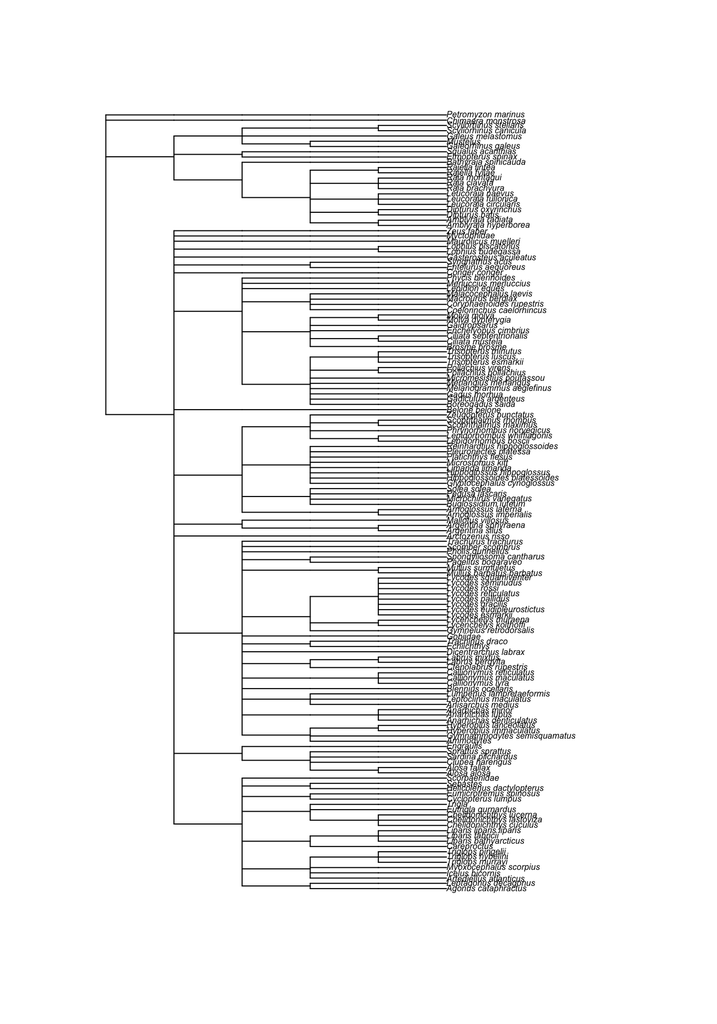

```r
plot(tree, cex=0.5)
```

# 2. Setting up the HMSC model

## 2.1 Define regression model for environmental covariates

```r
XFormula = as.formula(paste("~",paste(colnames(env), collapse="+")))
XFormula
```

```
## ~Depth + SBT + SBS + Chl + SBT_sea + Chl_sea + Fishing
```

You can also specify second order polynomial response terms for your regression model. Then HMSC fits both, the liner term and the quadratic term as covariates. Here, this is exemplified for SBT, SBS and Chl, where one could ecologically assume bell shaped responses. For reasons of simplicity, we continue with the above defined regression model.

*XFormula = ~ Depth + poly(SBT, degree = 2, raw= TRUE) + poly(SBT, degree = 2, raw= TRUE) + poly(SBS, degree = 2, raw= TRUE) + poly(Chl, degree = 2, raw= TRUE) + SBT_sea + Chl_sea + Fishing*

## 2.2 Define regression model for traits

```r
TrFormula = as.formula(paste("~",paste(colnames(trait), collapse="+")))
TrFormula
```

```
## ~Trophic.level + K + Lmax + Lifespan + Age.maturity + Fecundity_log +
##     Offspring.size_log
```

## 2.3 Set up study design with spatial random effect

```r
studyDesign = data.frame(grid.cell = as.factor(rownames(coo))) # "sample" level is defined as grid.cell
rL = HmscRandomLevel(sData = coo) # here the random effect is defined to be spatially explicit based on the coordinates of the grid cell
rL = setPriors(rL,nfMin=1,nfMax=2) # here we set the number of latent variable factors. In this example they are low for computational reasons

# Have a look at the random effect
rL
```

```
## Hmsc random level object with 169 units. Spatial dimensionality is 2 and number of covariates is 0.
```

```r
head(rL$s)
```

```
##      Longitude Latitude
## 1554    -28.75    66.25
## 1577    -26.25    63.75
## 1578    -26.25    66.25
## 1601    -23.75    63.75
## 1602    -23.75    66.25
## 1625    -21.25    63.75
```

## 2.4 Set up MCMC sample specifications

```r
test.run = TRUE # TEST RUN TAKES ABOUT 2 MIN ON MY COMPUTER
if (test.run){
  # with this option, the model runs fast but results are not reliable
  thin = 1 # interval of iterations per samples
  samples = 10 # number of samples taken per chain
  transient = ceiling(0.5*samples*thin) # burn-in, i.e. number of first iterations which will be cut off
  nChains = 2 # number of independent MCMC chains
} else {
  # with this option, the model evaluates slow but it reproduces the results shown in this tutorial
  thin = 100 # interval of iterations per samples
  samples = 250 # number of samples taken per chain
  transient = ceiling(0.5*samples*thin) # burn-in, i.e. number of first iterations which will be cut off
  nChains = 4 # number of independent MCMC chains
  }
```

## 2.4 Specify (unfitted) HMSC model structure

```r
m = Hmsc(Y= abu, XData = env,  XFormula = XFormula, TrFormula = TrFormula, TrData = trait, phyloTree = tree, studyDesign = studyDesign, ranLevels = list("grid.cell"= rL),  distr = "normal")
```

## 2.5 Fit and save model

```r
 m = sampleMcmc(m, thin = thin, samples = samples, transient = transient, nChains = nChains)

# You can also run chains in parallel by adding 'nParallel = nChains' in the sampleMCMC() function, but you won't see the progress of the run until it finished.

filename =  paste("NorthAtlantic","_thin_", as.character(thin),"_samples_", as.character(samples),"_chains_", as.character(nChains), ".Rdata",sep = "")

save(m,file=filename)
```

You can now either continue with the post-processing of the model with your fitted test run, or maybe better, load the for the course previously fitted model which used a higher thinning, more samples and chains, hence, included more iterations for better convergence of the MCMC chains.

```r
load("NorthAtlantic_rL_tree_thin_10_samples_250_chains_4.Rdata")
```

# 3. Check MCMC convergence diagnostics

```r
# convert model to coda object
mpost = convertToCodaObject(m)
```

You can visually check the MCMC convergence and mixing for beta (species-environment) and gamma (trait-environment) parameters

Since we have 7 environmental covariates and 148 species we get 1036 specific mixing plots for the beta parameters … not too convenient to go through.

*plot(mpost$Beta)*

Rather have a look at summarized diagnostics

```r
# check effective sample size
# should ideally be close to your drawn samples, here, 4 (chains) * 250 (samples) = 1000 samples)
summary(effectiveSize(mpost$Beta))
```

```
##    Min. 1st Qu.  Median    Mean 3rd Qu.    Max.
##   786.3   973.5  1000.0  1039.7  1073.1  3009.1
```

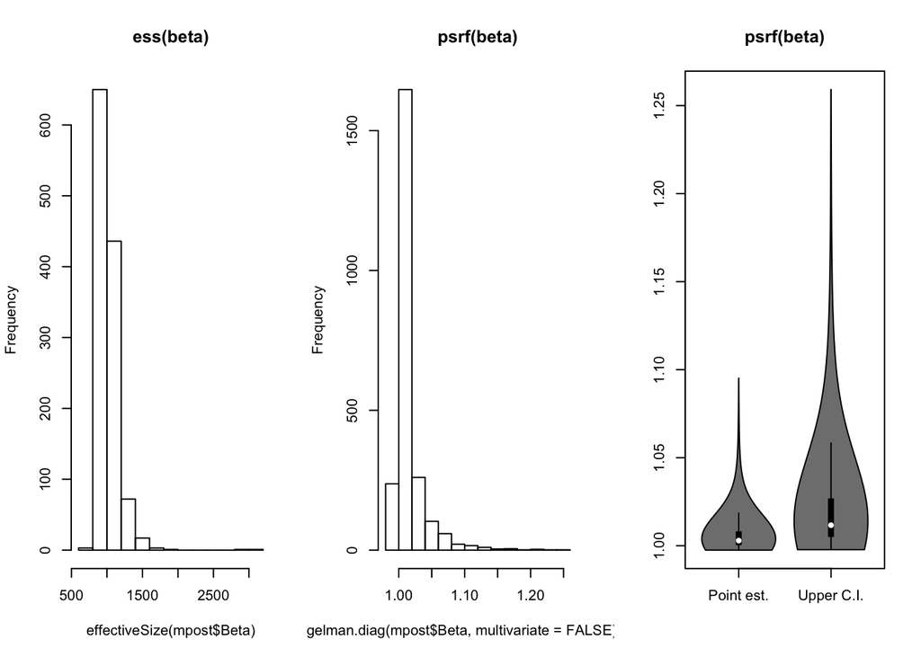

```r
# check the distribution of the effective sample size (ess) and the Gelman-Rubin potential scale reduction factor (psrf), the latter should be ideally (very) close to 1, if not, chains did not properly converge and need more iterations.
# These should be checked for all parameters of interest, i.e. beta and gamma
# Provided model looks quite okay already but could be better.

par(mfrow=c(1,3))
# Beta parameters (species-environment)
hist(effectiveSize(mpost$Beta), main="ess(beta)")
hist(gelman.diag(mpost$Beta, multivariate = FALSE)$psrf, main="psrf(beta)")
vioplot(gelman.diag(mpost$Beta,multivariate = FALSE)$psrf,main="psrf(beta)")
```

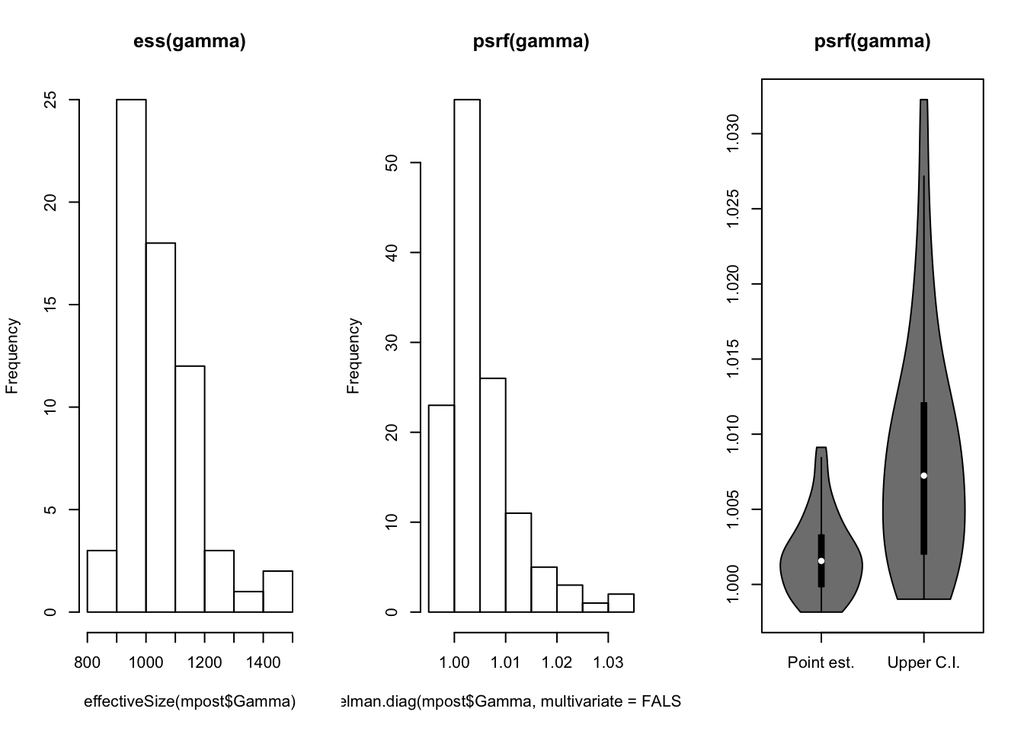

```r
# Gamma parameters (trait-environment)
hist(effectiveSize(mpost$Gamma), main="ess(gamma)")
hist(gelman.diag(mpost$Gamma, multivariate = FALSE)$psrf, main="psrf(gamma)")
vioplot(gelman.diag(mpost$Gamma,multivariate = FALSE)$psrf,main="psrf(gamma)")
```

# 4. Post process model results

## 4.1 Compute predicted values

```r
# compute predicted species abundance matrix/ posterior samples
predY=computePredictedValues(m)
```

## 4.2 Evaluate model fit (MF)

For our model type (abundance, normal distribution) MF provides two metrics, calculated for all individual species.

Root Mean Square Error ($RMSE) is the standard deviation of the residuals (prediction errors). Residuals are a measure of how far from the regression line data points are; RMSE is a measure of how spread out these residuals are. In other words, it tells you how concentrated the data is around the line of best fit.

R$^{2}$ ($R2): your “usual” measure of explained variation. Here prvided species specifically as result of the regression model (XFormula), with included enviornmental covariates

```r
MF = evaluateModelFit(hM = m, predY = predY)
MF
```

```
## $RMSE
##   [1] 0.0241029358 0.0014314489 0.0073169183 0.0187911408 0.0885159012
##   [6] 0.0346446105 0.0136305201 0.0943027509 0.0360033458 0.0208712288
##  [11] 0.0154651006 0.1461136596 0.1203870472 0.0408219267 0.0515242462
##  [16] 0.1210255635 0.0055227474 0.0005995548 0.0128888613 0.2045381038
##  [21] 0.0579907823 0.0367240697 0.0543206618 0.0523487887 0.0018713588
##  [26] 0.0433405301 0.0615989253 0.0079690515 0.0177833047 0.0849765722
##  [31] 0.0060515463 0.0011669438 0.1376531756 0.0258356317 0.0392692258
##  [36] 0.0162264416 0.0014285170 0.0304224151 0.0137556508 0.0134335595
##  [41] 0.0086522366 0.0373137086 0.0269322690 0.0591678346 0.0319173319
##  [46] 0.0637858504 0.0186484259 0.0894529194 0.1557369308 0.1736746185
##  [51] 0.0166861096 0.0037573490 0.0933817135 0.0470956150 0.0798659479
##  [56] 0.0521142782 0.0052529823 0.0070319185 0.1078269908 0.1851185561
##  [61] 0.0080399183 0.0027945350 0.0321503914 0.0729486076 0.0010771206
##  [66] 0.0015120361 0.0068494672 0.0894043068 0.1055254614 0.0739688439
```

[output cut: 43 more lines]

```r
mean(MF$R2)
```

```
## [1] 0.3793841
```

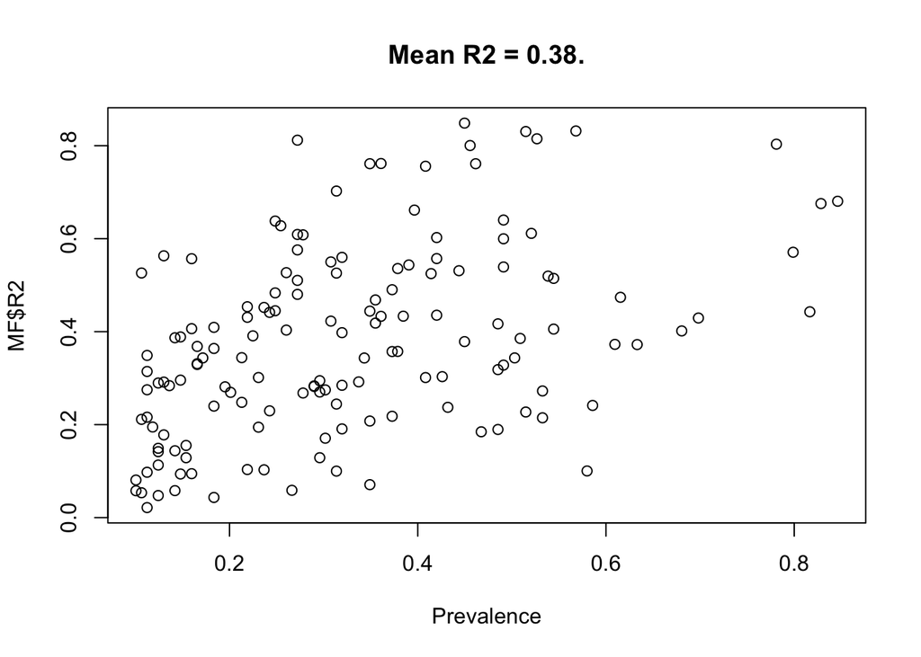

```r
#Here, we take the mean of posterior samples for further processing
predY = apply(abind(predY,along=3),c(1,2), mean)

# Plot species specific R2 in relation to prevalence
plot(colSums(((m$Y>0)*1)/m$ny), MF$R2,main=paste("Mean R2 = ", round(mean(MF$R2),2),".", sep=""), xlab = "Prevalence")
```

## 4.3 Plot species-environment relationships

```
## [1] 0.3 1.0 0.0 1.0
```

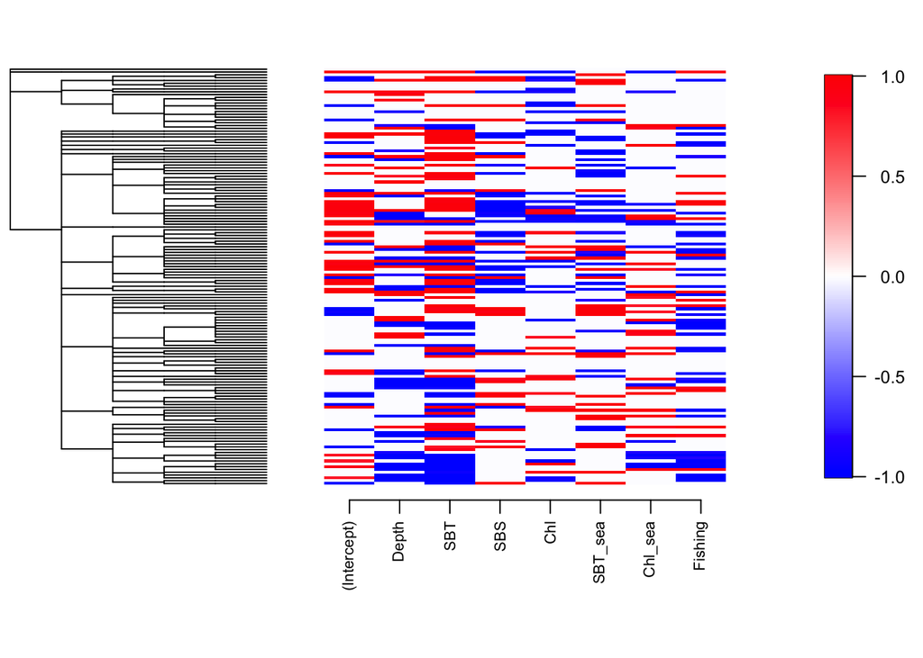

```r
# Shown are all species with 90% posterior support for having positive (red) or negative(blue) responses to environmental covariates
beta = getPostEstimate(m, "Beta")
plotBeta(m, beta, supportLevel=.9, spNamesNumbers = c(FALSE, FALSE), covNamesNumbers = c(TRUE, FALSE), plotTree = T)
```

## 4.3 Plot trait-environment relationships

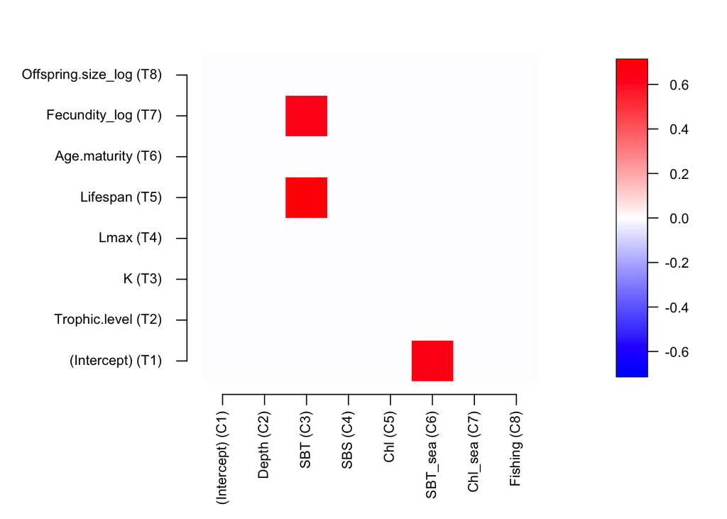

```r
gamma = getPostEstimate(m, "Gamma")
plotGamma(m, gamma, supportLevel=.8)
```

```r
# modify support level to highlight stronger or weaker posterior support for positive/ negative relationship
```

## 4.4 Varience Partitioning

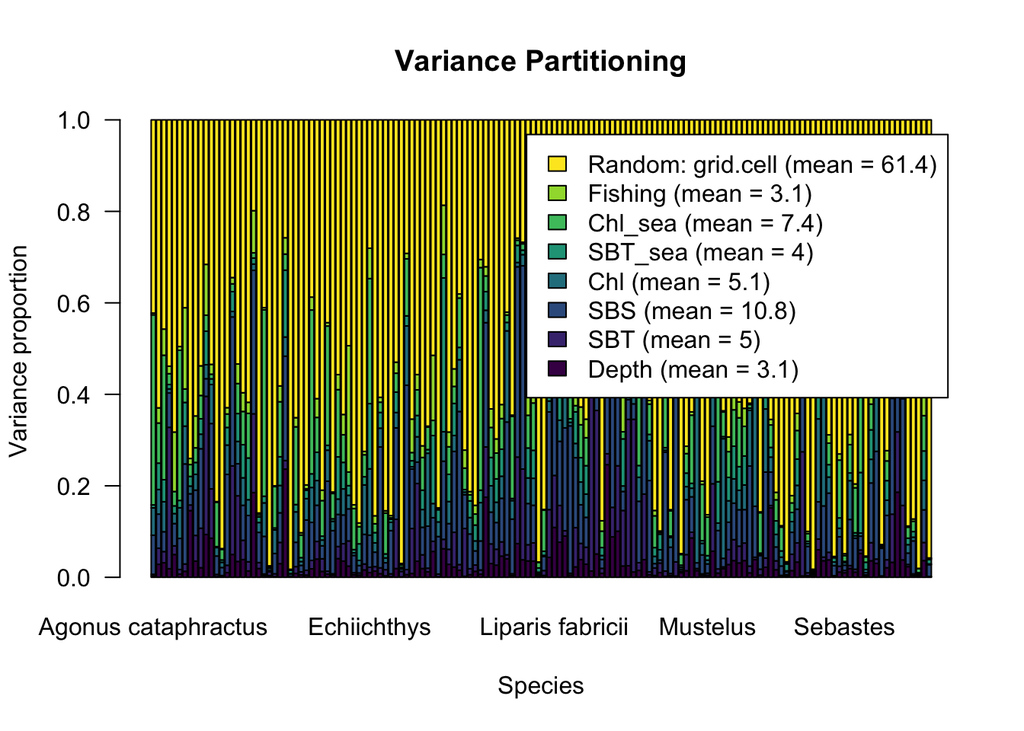

```r
par(mfrow=c(1,1))
# Specify groups of how the variation should be partitioned You can also combine groups
group=c(1,2,3,4,5,6,7)
# Specify group names m$covNames[-1] gives the included covariate names excluding the intercept
groupnames = m$covNames[-1]
#compte species specific variance partitioning
VP = computeVariancePartitioning(hM = m, group = group, groupnames = groupnames)

plotVariancePartitioning(m, VP, viridis(8)) #ignore random effect NA since we havn't specified a random effect
```

## 4.5 Trait specifc metrics

We can ask about the influence of traits on species abundances, i.e. how much do traits explain out of the variation in species abundances

```r
VP$R2T$Y
```

```
## [1] 0.01933062
```

```r
# The traits explain only 1.93% of variation in species abundances
```

Let us then ask how much the traits explain out of the variation among the species in their responses to environmental covariates.

```r
VP$R2T$Beta
```

```
## (Intercept)       Depth         SBT         SBS         Chl     SBT_sea
## 0.011770572 0.010954368 0.024170906 0.011867357 0.007802353 0.023027623
##     Chl_sea     Fishing
## 0.008830540 0.026924321
```

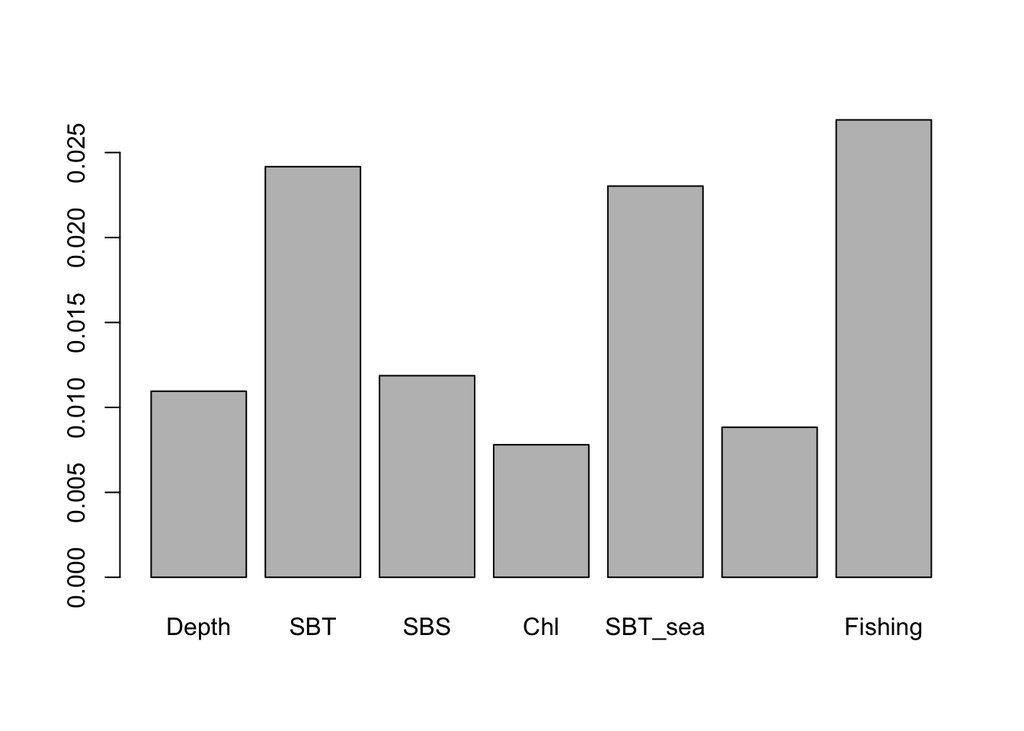

```r
barplot(VP$R2T$Beta[-1])
```

```r
#The traits explain also not much of the variation in the species niches, with traits explaining most out of the variation in species responses to SBT, SBT_sea and fishing with ca. 2.5% each
```

## 4.5 Trait-enviornment relationships

```r
# Construct environmental Gradient based on fitted model, specify your focal variable.
Gradient = constructGradient(m, focalVariable="SBT", ngrid = 25)
# make predictions based on fitted model
predYgradient = predict(m,XData=Gradient$XDataNew, ranLevels = Gradient$rLNew, studyDesign = Gradient$studyDesignNew, expected = TRUE)

par(mfrow=c(2,4))
# measure = T implies trait relationship to focal variable, index = 2 implies second trait of trait matrix (1 is the intercept).

# traits ~ SBT
plotGradient(m, Gradient, pred=predYgradient, measure="T", index = 2, showData =F)
```

```
## [1] 0.999
```

```r
plotGradient(m, Gradient, pred=predYgradient, measure="T", index = 3, showData =F)
```

```
## [1] 0.435
```

```r
plotGradient(m, Gradient, pred=predYgradient, measure="T", index = 4, showData =F)
```

```
## [1] 0.022
```

```r
plotGradient(m, Gradient, pred=predYgradient, measure="T", index = 5, showData =F)
```

```
## [1] 0.979
```

```r
plotGradient(m, Gradient, pred=predYgradient, measure="T", index = 6, showData =F)
```

```
## [1] 0.003
```

```r
plotGradient(m, Gradient, pred=predYgradient, measure="T", index = 7, showData =F)
```

```
## [1] 0.987
```

```r
plotGradient(m, Gradient, pred=predYgradient, measure="T", index = 8, showData =F)
```

```
## [1] 0.048
```

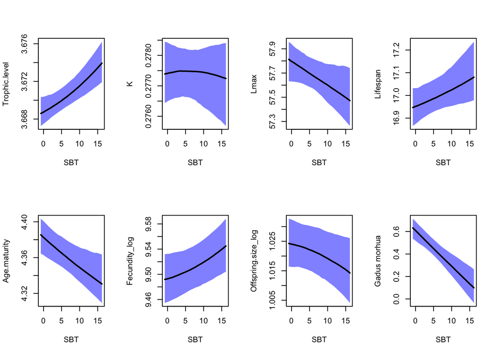

```
## [1] 0
```

```r
# Species  ~ SBT // If you specify measure = Y, this is the species response, with index being the number of species in the abu matrix
plotGradient(m, Gradient, pred=predYgradient, measure="Y", index = 50, showData =F) #here examplified for species 50, cod
```

```r
# Note that the scale of all relationships is very small for the traits
```

## Plotting predicted trait distribution over space

```r
S=rowSums(predY)
#predicted CWM
predT = (predY%*%m$Tr)/matrix(rep(S,m$nt),ncol=m$nt)

#make data frame for plotting
data<-data.frame(predT, coo)
colpal<-rev(brewer.pal(11,"RdYlBu")) # Color palette for the map

funPlot<-function(Var){
colnames(data)[which(colnames(data)==Var)]<-"Var"
ggplot(data, aes(x= Longitude, y= Latitude, fill= Var))+
  geom_tile(data=data,aes(x=Longitude,y=Latitude,fill= Var)) + #
  scale_fill_gradientn(name = Var, colours=colpal, na.value = 'white')+
  borders(fill="gray44",colour="black") +
  coord_quickmap(xlim=c(range(data$Longitude)),ylim=c(range(data$Latitude)))+
  labs(x = "Lon",y="Lat")+
  theme(legend.position = c(0.93,0.8))+
  theme(legend.title = element_text(size = 8),legend.text = element_text(size = 7))+
  guides(shape = guide_legend(override.aes = list(size = 0.2)))+
  theme(panel.background = element_rect(fill=alpha('light blue', 0.4), colour = 'black'))
}
# list all output
Metrics<-colnames(data)
Metrics
```

```
##  [1] "X.Intercept."       "Trophic.level"      "K"
##  [4] "Lmax"               "Lifespan"           "Age.maturity"
##  [7] "Fecundity_log"      "Offspring.size_log" "Longitude"
## [10] "Latitude"
```

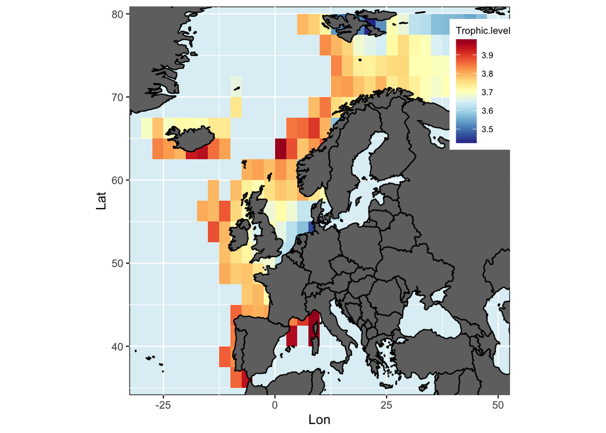

```r
#We plot the CWM of Trophic level, which is the 2nd variable
funPlot(Var=Metrics[2])# Plot CWM traits and diversity metrics
```

## 4.6 Species co-occurrance patterns at random effect level

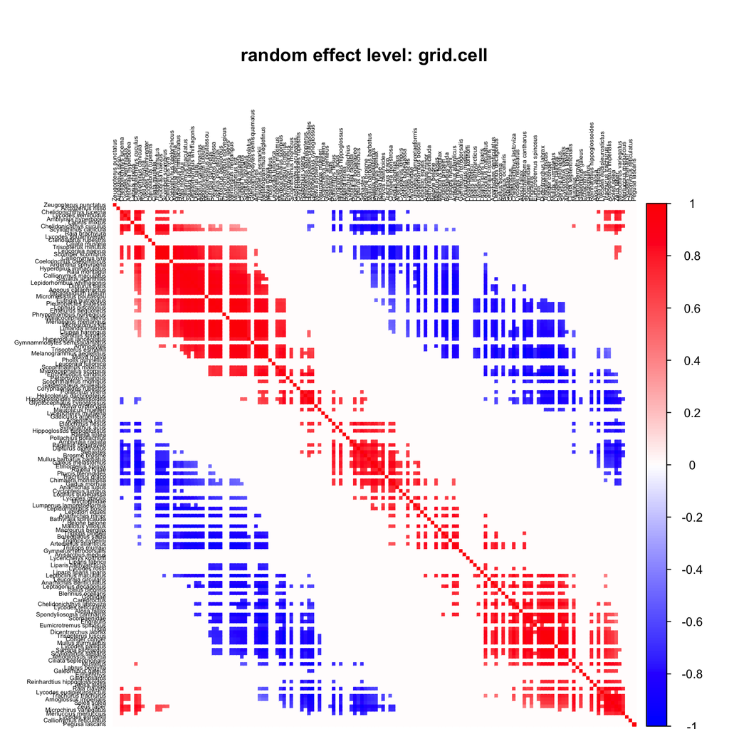

```r
par(mfrow=c(1,1))
OmegaCor = computeAssociations(m)
supportLevel = 0.9
for (r in 1:m$nr){
  plotOrder = corrMatOrder(OmegaCor[[r]]$mean,order="AOE")
  toPlot = ((OmegaCor[[r]]$support>supportLevel) +                                    (OmegaCor[[r]]$support<(1-supportLevel))>0)*OmegaCor[[r]]$mean
  par(xpd=T)
  colnames(toPlot)=rownames(toPlot)=gsub("_"," ",x=colnames(toPlot))
  corrplot(toPlot[plotOrder,plotOrder], method = "color", col=colorRampPalette(c("blue","white","red"))(200), title=paste("random effect level:",m$rLNames[r]),type="full",tl.col="black",tl.cex=.4, mar=c(0,0,6,0))
}
```